# Scatter, Box, and Violin Plots

## Categorical Variables

To avoid over-plotting, the plot of two categorical variables results in a bubble plot of their joint frequencies.

```r
d <- Read("Employee", quiet=TRUE)
```

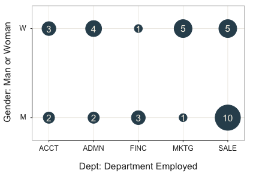

```
## Joint and Marginal Frequencies
## ------------------------------
##
##        Dept
## Gender   ACCT ADMN FINC MKTG SALE Sum
##   M         2    2    3    1   10  18
##   W         3    4    1    5    5  18
##   Sum       5    6    4    6   15  36
##
## Cramer's V: 0.415
##
## Chi-square Test of Independence:
##      Chisq = 6.200, df = 4, p-value = 0.185
## >>> Low cell expected frequencies, chi-squared approximation may not be accurate
##
## Some Parameter values (can be manually set)
## -------------------------------------------------------
## radius: 0.22    size of largest bubble
## power: 0.50     relative bubble sizes
```

```r
Plot(Dept, Gender)
```

The parameter `radius` scales the size of the bubbles according to the size of the largest displayed bubble in inches. The `power` parameter sets the relative size of the bubbles. The default `power` value of 0.5 scales the bubbles so that the area of each bubble is the value of the corresponding sizing variable. A value of 1 scales so the radius of each bubble is the value of the sizing variable, increasing the discrepancy of size between the variables.

In this example, increase the absolute size of the bubbles as well as the relative discrepancy in their sizes. If the bubbles become too large, so that the largest bubbles become truncated, increase the spacing of the respective axes with the `pad_x` and/or `pad_y` parameters.

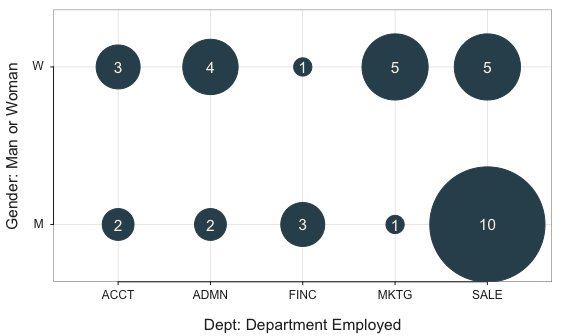

```
## Joint and Marginal Frequencies
## ------------------------------
##
##        Dept
## Gender   ACCT ADMN FINC MKTG SALE Sum
##   M         2    2    3    1   10  18
##   W         3    4    1    5    5  18
##   Sum       5    6    4    6   15  36
##
## Cramer's V: 0.415
##
## Chi-square Test of Independence:
##      Chisq = 6.200, df = 4, p-value = 0.185
## >>> Low cell expected frequencies, chi-squared approximation may not be accurate
##
## Some Parameter values (can be manually set)
## -------------------------------------------------------
## radius: 0.60    size of largest bubble
## power: 0.80     relative bubble sizes
```

```r
Plot(Dept, Gender, radius=.6, power=0.8, pad_x=0.05, pad_y=0.05)
```

Alternatively, plot two categorical variables with a Trellis (facet) chart by invoking the `by1` parameter. If the first listed variable in the function call, the `x` parameter, is categorical, the result is a dot chart for each level of the `by1` variable.

```
## [Trellis graphics from Deepayan Sarkar's lattice package]
```

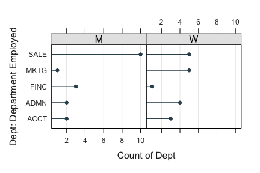

```r
Plot(Dept, by1=Gender)
```

Plotting a single categorical variable yields the corresponding bubble plot of frequencies.

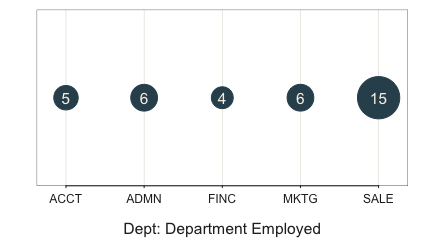

```
## >>> Suggestions
## Plot(Dept, color_low="lemonchiffon2", color_hi="maroon3")
## Plot(Dept, values="count")  # scatter plot of counts
##
## --- Dept ---
##
##                 ACCT   ADMN   FINC   MKTG   SALE    Total
## Frequencies:       5      6      4      6     15       36
## Proportions:   0.139  0.167  0.111  0.167  0.417    1.000
##
## Chi-squared test of null hypothesis of equal probabilities
##   Chisq = 10.944, df = 4, p-value = 0.027
```

```
##
##
##
## Some Parameter values (can be manually set)
## -------------------------------------------------------
## radius: 0.22    size of largest bubble
## power: 0.50     relative bubble sizes
```

```r
Plot(Dept)
```

## Interactive Plots

An interactive visualization lets the user in real time change parameter values to change characteristics of the visualization. To create an interactive two-variable scatterplot of continuous variables with the employee data that displays the corresponding parameters, run the function `interact()` with `"ScatterPlot"` specified.

```
interact("ScatterPlot")
```

To create an interactive Trellis plot as a combined violin, box, and scatter plot with the five values of Dept from the Employee data set that displays the corresponding parameters, run the function `interact()` with `"Trellis"` specified.

```
interact("Trellis")
```

The functions are not run here because interactivity requires to run directly from the R console.

## Full Manual

Use the base R `help()` function to view the full manual for `Plot()`. Simply enter a question mark followed by the name of the function.

```
?Plot
```

## More

More on Scatterplots, Time Series plots, and other visualizations from **lessR** and other packages such as **ggplot2** at:

Gerbing, D., *R Visualizations: Derive Meaning from Data*, CRC Press, May, 2020, ISBN 978-1138599635.